# Analysis of phylogeny

```r
library(phytools)
library(dplyr)
library(tidyverse)
rm(list = ls())
```

- Species analysis

- Species present in birdlife regional pool.

Load a maximum clade credibility tree from jetz

`r tree <- read.tree("./phylogeny__input__stage2_hackett_mcc_no_neg.tre")`

Load BirdLife regional pool species and city data

`r birdlife_species_raw <- read_csv('./phylogeny__input__birdlife_species_presence.csv')`

[output not shown]

`r birdlife_species_input`

Show the results for species

`r birdlife_species_continuous_trait_evolution <- contMap(birdlife_species_pruned, species_response, outline=FALSE, fsize=0.05, lwd=0.3)`

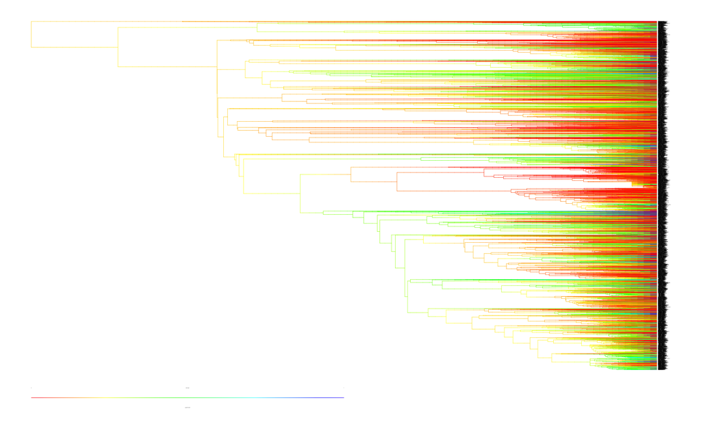

Produce a circular plot with family name arcs over species

Change colour ramp

```r
colourCount <- length(birdlife_species_continuous_trait_evolution$cols)
birdlife_species_continuous_trait_evolution$cols[1:colourCount]<-colorRampPalette(c("#FFC20A","#0C7BDC"), space="Lab")(colourCount)
```

To produce family names as arcs over species function from: http://blog.phytools.org/2017/03/clade-labels-on-circular-fan-tree.html adapted due to: https://github.com/liamrevell/phytools/issues/79

```r
library(plotrix)
arc.cladelabels.fixed <- function(tree=NULL,text,node=NULL,ln.offset=1.02,
    lab.offset=1.06,cex=1,orientation="curved",...){
    obj<-get("last_plot.phylo",envir=.PlotPhyloEnv)
    if(obj$type!="fan") stop("method works only for type=\"fan\"")
    h<-max(sqrt(obj$xx^2+obj$yy^2))
    if(hasArg(mark.node)) mark.node<-list(...)$mark.node
    else mark.node<-TRUE
    if(hasArg(interactive)) interactive<-list(...)$interactive
    else {
        if(is.null(node)) interactive<-TRUE
        else interactive<-FALSE
    }
    if(interactive) node<-getnode()
    if(hasArg(lwd)) lwd<-list(...)$lwd
    else lwd<-par()$lwd
    if(hasArg(col)) col<-list(...)$col
    else col<-par()$col
    if(hasArg(lend)) lend<-list(...)$lend
    else lend<-par()$lend
    if(hasArg(clockwise)) clockwise<-list(...)$clockwise
    else clockwise<-TRUE
    if(hasArg(n)) n<-list(...)$n
    else n<-0.05
    if(mark.node) points(obj$xx[node],obj$yy[node],pch=21,
        bg="red")
    if(is.null(tree)){
        tree<-list(edge=obj$edge,tip.label=1:obj$Ntip,
            Nnode=obj$Nnode)
        class(tree)<-"phylo"
    }
    d<-getDescendants(tree,node)
    d<-sort(d[d<=Ntip(tree)])

    deg<-atan(obj$yy[d]/obj$xx[d])*180/pi

    ii<-intersect(which(obj$yy[d]>=0),which(obj$xx[d]<0))
    deg[ii]<-180+deg[ii]

    ii<-intersect(which(obj$yy[d]<0),which(obj$xx[d]<0))
    deg[ii]<-180+deg[ii]

    ii<-intersect(which(obj$yy[d]<0),which(obj$xx[d]>=0))
    deg[ii]<-360+deg[ii]

    deg1 <- min(deg, na.rm = T)
    deg2 <- max(deg, na.rm = T)
    #draw.arc(x=0,y=0,radius=ln.offset*h,deg1=deg1, deg2=deg2,lwd=lwd,col=col,lend=lend,n=n)

    if(orientation=="curved")
        arctext(text, radius=lab.offset*h, middle=mean(range(deg * pi/180, na.rm = T)), cex=cex, clockwise=clockwise)
    else if(orientation=="horizontal") {
      deg_med <- median(deg, na.rm = T)
        x0<-lab.offset * cos(deg_med*pi/180)*h
        y0<-lab.offset * sin(deg_med*pi/180)*h
        text(x=x0,y=y0,label=text,
        adj=c(if(x0>=0) 0 else 1,if(y0>=0) 0 else 1),
        offset=0,cex=cex)
    }
}
```

All family names present in CTE

```r
sort(unique(birdlife_species_input$birdlife_v3_family_name_english))
```

```
  [1] "Accentors"                                   "Anhingas"                                    "Antbirds"                                    "Antthrushes and antpittas"
  [5] "Australasian babblers"                       "Australasian robins"                         "Australasian wrens"                          "Australian mudnesters"
  [9] "Australian treecreepers"                     "Babblers and parrotbills"                    "Bananaquit"                                  "Barn owls"
 [13] "Bee-eaters"                                  "Bowerbirds"                                  "Bristlebirds"                                "Broadbills"
 [17] "Bulbuls"                                     "Buntings, American sparrows and allies"      "Bustards"                                    "Butcherbirds"
 [21] "Buttonquails"                                "Chats and Old World flycatchers"             "Cisticolas and allies"                       "Cormorants"
 [25] "Cotingas"                                    "Coursers and pratincoles"                    "Crab Plover"                                 "Cranes"
 [29] "Crows and jays"                              "Cuckoo-Roller"                               "Cuckoo-shrikes"                              "Cuckoos"
 [33] "Dippers"                                     "Doves and pigeons"                           "Drongos"                                     "Ducks, geese and swans"
 [37] "Emus"                                        "Fairy-bluebirds"                             "Falcons and caracaras"                       "Fantails"
 [41] "Finches and Hawaiian honeycreepers"          "Finfoots"                                    "Flamingos"                                   "Flowerpeckers"
 [45] "Frogmouths"                                  "Gnatcatchers"                                "Gnateaters"                                  "Goldcrests and kinglets"
 [49] "Grebes"                                      "Grosbeaks, saltators and allies"             "Ground-hornbills"                            "Grouse, pheasants and partridges"
 [53] "Guans and curassows"                         "Guineafowl"                                  "Gulls and terns"                             "Hammerkop"
 [57] "Helmetshrikes, bushshrikes and puffbacks"    "Herons and egrets"                           "Hoatzin"                                     "Honeyeaters"
```

[output cut: 27 more lines]

Where do the labels appear on the plot

```r
birdlife_jitter_down = c('Orioles and figbirds', 'Long-tailed Tits', 'Honeyguides', 'Ground-hornbills', 'Sunbirds', 'New World blackbirds', 'Mockingbirds and thrashers', 'Grosbeaks, saltators and allies', 'Nightjars', 'Ducks, geese and swans', 'Treecreepers', 'Guans and curassows', 'Thrushes', 'Grouse, pheasants and partridges', 'Helmetshrikes, bushshrikes and puffbacks', 'Starlings', 'Jacanas', 'New World warblers', 'Kingfishers', 'Antthrushes and antpittas', 'Pardalotes', 'Honeyeaters', 'Vireos and allies', 'Australasian babblers', 'Vireos and allies', 'Shrike-tits', 'Australasian wrens', 'Woodswallows', 'Shrike-flycatchers, wattle-eyes and batises', 'White-eyes', 'Frogmouths', 'Woodpeckers', 'Pardalotes', 'Tits and chickadees', 'Motmots', 'Accentors', 'Sparrows, snowfinches and allies', 'Herons and egrets', 'Drongos', 'Trogons', 'Manakins', 'Babblers and parrotbills', 'Sandgrouse', 'Old World warblers')

birdlife_jitter_down_down = c('Pardalotes', 'Antthrushes and antpittas', 'Rollers', 'Buttonquails', 'Swallows and martins', 'Guineafowl', 'Gnateaters', 'Shrike-flycatchers, wattle-eyes and batises', 'Turacos', 'Lyrebirds', 'Flowerpeckers', 'Penduline-tits', 'Waxbills, grass finches, munias and allies')

birdlife_jitter_up = c('Wrens', 'Screamers', 'Coursers and pratincoles', 'Butcherbirds', 'Indigobirds and allies', 'Antbirds', 'Bee-eaters', 'Gnateaters', 'Rails, crakes and allies', 'Tinamous', 'Cuckoo-shrikes', 'Storks', 'Painted-snipes', 'Wagtails and pipits', 'Weavers and allies', 'Puffbirds', 'Ovenbirds', 'Osprey, kites, hawks and eagles', 'Waxwings', 'Bustards', 'Australian treecreepers', 'Cuckoos', 'Crows and jays', 'Cotingas', 'Chats and Old World flycatchers', 'Flamingos', 'Parrots', 'Stilts and avocets')

birdlife_jitter_up_up = c('Larks', 'Broadbills', 'Butcherbirds', 'Woodhoopoes', 'Toucans and barbets', 'New World vultures', 'Honeyeaters', 'Anhingas', 'Australasian robins', 'Lyrebirds', 'Sparrows, snowfinches and allies', 'Ibises and spoonbills', 'Whipbirds, wedgebills and jewel-babblers', 'Leafbirds', 'Shrikes', 'Falcons and caracaras')

birdlife_jitter_up_up_up = c('Oystercatchers', 'Pelicans', 'Thick-knees', 'Goldcrests and kinglets')
```

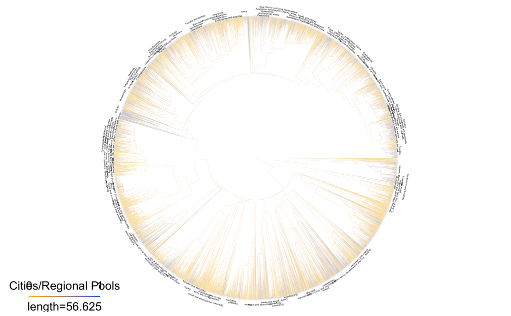

```r
plot(birdlife_species_continuous_trait_evolution, type="fan", outline=FALSE, fsize=c(0.01, 1), lwd = c(0.1, 1), leg.txt="Cities/Regional Pools")

for(family in unique(birdlife_species_input$birdlife_v3_family_name_english)) {
  col = "black"
  lab.offset = 1.04
  ln.offset = 1.00

  if (family %in% birdlife_jitter_down) {
    lab.offset = 1.025
  }

  if (family %in% birdlife_jitter_up) {
    lab.offset = 1.055
  }

  if (family %in% birdlife_jitter_up_up) {
    lab.offset = 1.07
  }

  if (family %in% birdlife_jitter_up_up_up) {
    lab.offset = 1.085
  }

  if (family %in% birdlife_jitter_down_down) {
    lab.offset = 1.01
  }

  tips <- birdlife_species_input$jetz_scientific_name[birdlife_species_input$birdlife_v3_family_name_english == family]
  node <- findMRCA(tree, tips)
  tryCatch(
    expr = {
      arc.cladelabels.fixed(text=family, node=node, tree = tree, cex = 0.2, mark.node = F, col = col, lab.offset = lab.offset, ln.offset = ln.offset)
    },
    error=function(e){}
  )
}
```

Save the results

```r
pdf(file="phylogeny__output__birdlife_species_tree.pdf")
plot(birdlife_species_continuous_trait_evolution, type="fan", outline=FALSE, fsize=c(0.01, 0.5), lwd = c(0.1, 1), leg.txt="Cities/Regional Pools")

for(family in unique(birdlife_species_input$birdlife_v3_family_name_english)) {
  col = "black"
  lab.offset = 1.04
  ln.offset = 1.00

  if (family %in% birdlife_jitter_down) {
    lab.offset = 1.025
  }

  if (family %in% birdlife_jitter_up) {
    lab.offset = 1.055
  }

  if (family %in% birdlife_jitter_up_up) {
    lab.offset = 1.07
  }

  if (family %in% birdlife_jitter_up_up_up) {
    lab.offset = 1.085
  }

  if (family %in% birdlife_jitter_down_down) {
    lab.offset = 1.01
  }

  tips <- birdlife_species_input$jetz_scientific_name[birdlife_species_input$birdlife_v3_family_name_english == family]
  node <- findMRCA(tree, tips)
  tryCatch(
    expr = {
      arc.cladelabels.fixed(text=family, node=node, tree = tree, cex = 0.2, mark.node = F, col = col, lab.offset = lab.offset, ln.offset = ln.offset)
    },
    error=function(e){}
  )
}
dev.off()
```

| - Family analysis |
| --- |

Families present in birdlife regional pool.

Load a maximum clade credibility tree from jetz

```r
ftree <- read.tree("./phylogeny__input__family_tree_18Aug2020.tre")
```

Load BirdLife regional pool family and city data

```r
birdlife_family_raw <- read_csv('./phylogeny__input__birdlife_family_presence.csv')
head(birdlife_family_raw)
```

| birdlife_v3_family_name | city_count | region_count | presence_ratio |
| --- | --- | --- | --- |
| Acanthizidae | 7 | 7 | 1.000 |
| Musophagidae | 7 | 9 | 0.778 |
| Platysteiridae | 5 | 10 | 0.500 |
| Viduidae | 5 | 11 | 0.455 |
| Malaconotidae | 9 | 12 | 0.750 |
| Rhinocryptidae | 2 | 12 | 0.167 |

Species from birdlife pool not in tree

```r
birdlife_family_raw[!birdlife_family_raw$birdlife_v3_family_name %in% ftree$tip.label,]
```

| birdlife_v3_family_name | city_count | region_count | presence_ratio |
| --- | --- | --- | --- |

Format birdlife data, using only species in tree

```r
birdlife_family_input <- birdlife_family_raw[birdlife_family_raw$birdlife_v3_family_name %in% ftree$tip.label,]
birdlife_family_pruned <- ladderize(drop.tip(ftree, setdiff(ftree$tip.label, birdlife_family_input$birdlife_v3_family_name)))

family_response <- birdlife_family_input$presence_ratio
names(family_response) <- birdlife_family_input$birdlife_v3_family_name

family_response
```

```
     Acanthizidae      Musophagidae    Platysteiridae          Viduidae     Malaconotidae    Rhinocryptidae     Indicatoridae          Pipridae        Bucconidae     Formicariidae
            1.000             0.778             0.500             0.455             0.750             0.167             0.308             0.308             0.077             0.200
   Thamnophilidae          Cracidae        Cotingidae         Tinamidae       Furnariidae        Thraupidae         Artamidae    Odontophoridae       Pteroclidae     Polioptilidae
            0.706             0.556             0.421             0.211             0.800             0.917             0.467             0.286             0.029             0.694
     Rhipiduridae         Remizidae        Vireonidae       Bucerotidae       Trochilidae      Cardinalidae           Mimidae         Parulidae        Trogonidae         Dicaeidae
            0.595             0.275             0.881             0.512             0.977             0.837             0.814             0.884             0.068             0.614
       Tyrannidae         Icteridae          Pittidae          Otididae         Ploceidae     Nectariniidae        Dicruridae           Gruidae        Turnicidae     Campephagidae
            1.000             0.909             0.114             0.020             0.596             0.914             0.778             0.125             0.046             0.446
     Zosteropidae        Burhinidae      Ramphastidae       Monarchidae         Meropidae        Timaliidae       Estrildidae       Glareolidae      Pycnonotidae         Oriolidae
            0.667             0.212             0.776             0.478             0.700             0.767             0.747             0.080             0.974             0.518
     Cisticolidae     Troglodytidae        Coraciidae          Sittidae      Muscicapidae Threskiornithidae         Sylviidae           Paridae        Ciconiidae       Psittacidae
            0.798             0.729             0.264             0.374             0.958             0.611             0.938             0.500             0.315             0.778
         Laniidae         Alaudidae       Phasianidae Phalacrocoracidae         Sturnidae         Tytonidae      Fringillidae       Emberizidae      Motacillidae        Passeridae
            0.629             0.470             0.581             0.798             0.892             0.081             0.664             0.532             0.826             0.955
          Picidae         Cuculidae     Podicipedidae       Alcedinidae     Caprimulgidae          Corvidae           Laridae          Turdidae          Apodidae         Strigidae
            0.828             0.711             0.706             0.854             0.226             0.812             0.623             0.777             0.799             0.560
         Rallidae        Columbidae        Falconidae      Charadriidae      Scolopacidae          Anatidae      Accipitridae          Ardeidae      Hirundinidae
            0.865             1.000             0.660             0.745             0.730             0.759             0.865             0.915             0.915
```

```r
birdlife_family_phylo_signal <- phylosig(birdlife_family_pruned, family_response, method="lambda", test=TRUE)
birdlife_family_phylo_signal
```

```
Phylogenetic signal lambda : 0.910366
logL(lambda) : -9.36705
LR(lambda=0) : 7.02341
P-value (based on LR test) : 0.00804507
```

Show the results for families

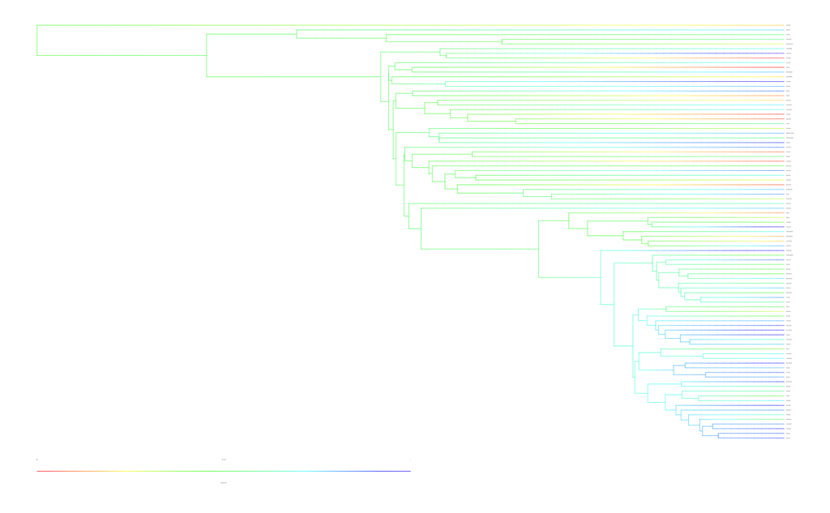

```r
birdlife_family_continuous_trait_evolution <- contMap(birdlife_family_pruned, family_response, outline=FALSE, fsize=0.05, lwd=0.3)
```

Change colour ramp

```r
colourCount <- length(birdlife_family_continuous_trait_evolution$cols)
birdlife_family_continuous_trait_evolution$cols[1:colourCount]<-colorRampPalette(c("#c2cc31","#3134cc"), space="Lab")(colourCount)
```

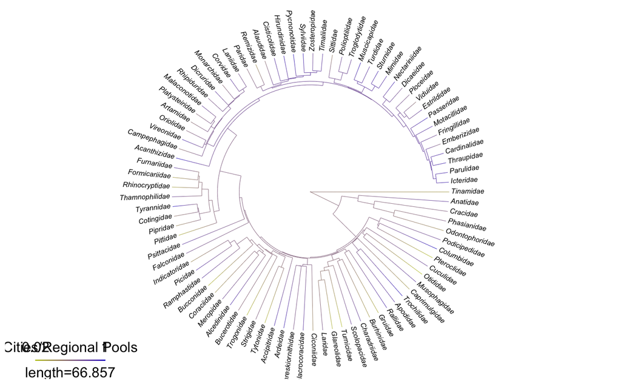

```r
plot(birdlife_family_continuous_trait_evolution, type="fan", outline=FALSE, fsize=c(0.5, 1), lwd = c(0.5, 1), leg.txt="Cities/Regional Pools")
```

Save the results

```r
jpeg(file="phylogeny__output__birdlife_family_tree.jpg", width = 2056, height=2056)
plot(birdlife_family_continuous_trait_evolution, type="fan", outline=FALSE, fsize=2, lwd = c(20, 10), cex.legend=0.5, leg.txt="Cities/regional pools")
dev.off()
```

```r
birdlife_family_input[order(-birdlife_family_input$presence_ratio),c('birdlife_v3_family_name', 'presence_ratio')]
```

| birdlife_v3_family_name | presence_ratio |
| --- | --- |
| Acanthizidae | 1.000 |
| Tyrannidae | 1.000 |
| Columbidae | 1.000 |
| Trochilidae | 0.977 |
| Pycnonotidae | 0.974 |
| Muscicapidae | 0.958 |
| Passeridae | 0.955 |
| Sylviidae | 0.938 |
| Thraupidae | 0.917 |
| Ardeidae | 0.915 |

[output cut: 79 more lines]